# Inverts User Manual

## 10.3 Implementing effort limits

Lets say you wanted to test a set of levels for a particular management measure. Here we are going to investigate various levels of current fishing pressure (this could be managed by access limits, seasonal spatial closures, license limits etc). You can see from the code above that this would be cumbersome for more than a few MPs. To avoid the mess, the Inverts package comes with a function for spawning multiple MPs from differing values of a particular argument:

```r
Effs = c(1,2,4,8,16)
E_MPs = paste0("E",Effs)
spawnMP("MP.MC", spawnlist = list(CEff.Mult = Effs), spawnnames = E_MPs)
```

Based on our status quo management procedure, in just three lines of code we have successfully made a set of 5 MPs (with names E1, E2, E4, E8, E16) that fish at between 1x and 16x current effort levels.

We can now test those:

```r
MSE_Eff = Project(Hist, E_MPs)
```

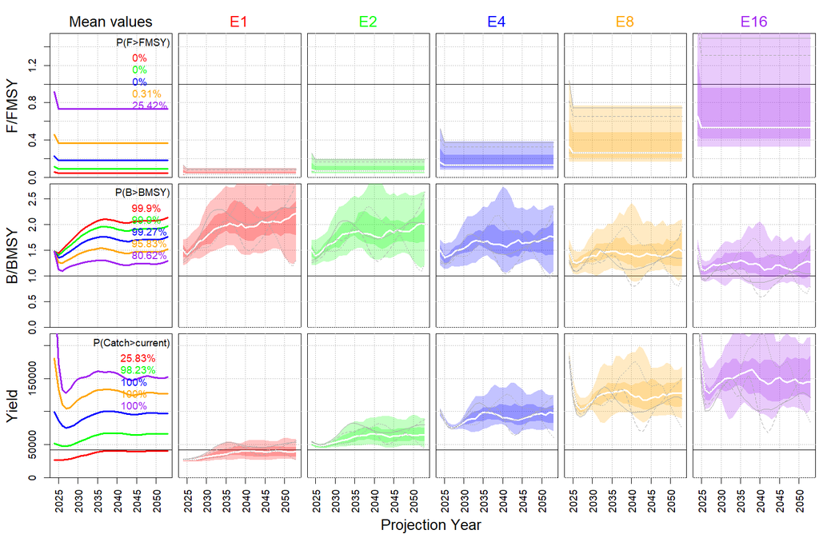

```r
Splot(MSE_Eff)
```

These plots show the fundamental trade-off between what is taken (yield) and what is left over in the water (biomass). We can created custom trade-off plot to show this more clearly:

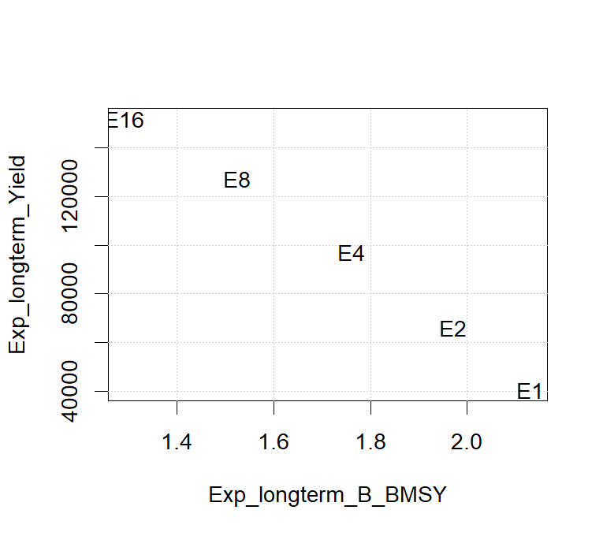

```r
Exp_longterm_B_BMSY = apply(MSE_Eff@SB_SBMSY[,,30],2,mean)
Exp_longterm_Yield = apply(MSE_Eff@Catch[,,30],2,mean)
plot(Exp_longterm_B_BMSY,Exp_longterm_Yield, col="white");grid()
text(Exp_longterm_B_BMSY,Exp_longterm_Yield, MSE_Eff@MPs)
```

## 10.4 Index ratio approaches

By default, the invertebrate MPs fish at current fishing effort levels without total allowable catch (TAC) control. You may however wish to invetigate options that explicity set catch limits. The simplest way to do this are empirical management procedures that use data directly and do not require an estimation / assessment step. These are increasingly applied in the management of a very wide range of fish species and their adoption is the principle objective of MSE in most fishery settings.

The most commonly applied type of empirical management procedure aims to fish at a stable exploitation rate by setting catch limits to a fixed multiple of a relative abundance index:

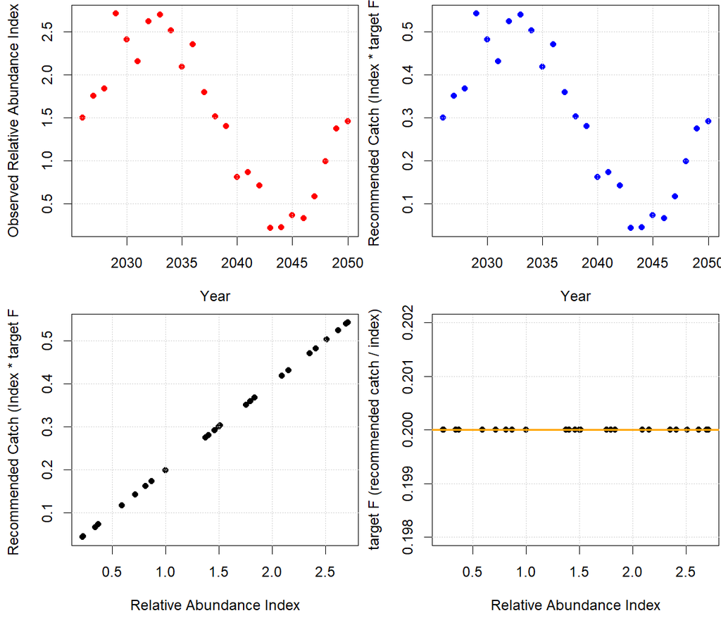

Constant exploitation rates already include a degree of precaution since equilibrium sustainable exploitation rates increase exponentially as stocks decline. For example, in most cases it is necessary to fish at levels larger than two or three times FMSY to sustainably deplete a stock below half BMSY:

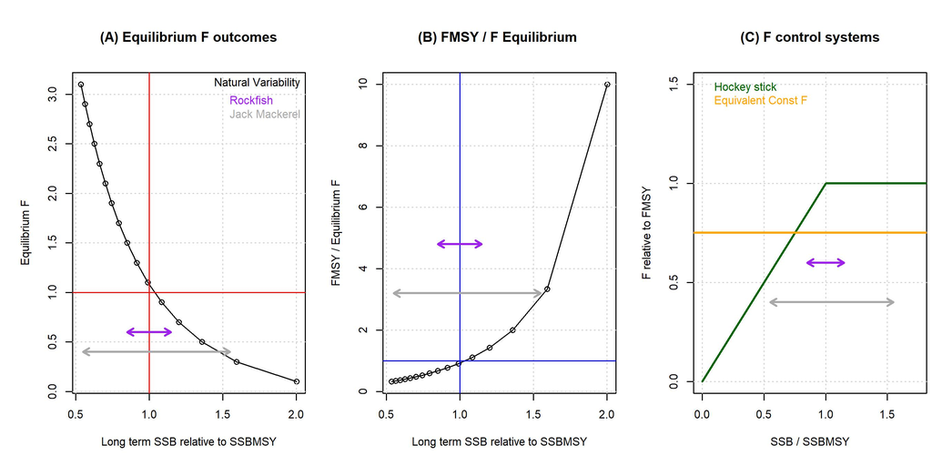

Nevertheless, in Canada, fisheries management often seeks to impose an additional ‘hockey stick’ harvest control rule (an algorithm that throttles exploitation rate as stock biomass declines - the green line of the plot above). Hockey stick harvest control rules require control points for the maximum exploitation rate (y axis) and the biomass (x axis) below which exploitation rate is reduced and where exploitation rate is zero.

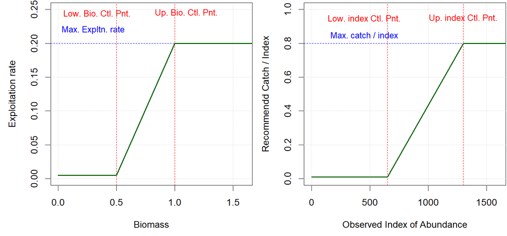

In the figure above the harvest control rule for which Exploitation rate is a function of biomass (left panel), can be rephrased as an empirical rule based on observed catches and an observed Index of abundance (right panel). The control points are then phrased in terms of the recommended catch per index (exploitation rate) and the index levels below which catches are zero or catch per index is reduced.

The status quo MPs have the option of specifying control using such a system. The arguments for this function are explained in the help documentation:

```r
objs('MP') # what inverts-specific MPs are available?
```

```
#> Searching for objects of class MP in package: Inverts
#> Searching for objects of class MP in package: Inverts.GD
#> Searching for objects of class MP in package: Inverts.MC
#> [1] "MP.GD" "MP.MC"
```

```r
?MP.MC     # help documentation for MP.GD
args(MP.MC)# a more concise list of arguments to the function
```

```
#> function (x, Data, reps = 1, Min.size = 35, Max.size = NaN, CEff.Mult = 1,
#>     C_I.targ = 1, I.targ = 0.5, IS.targ = 0, IS.yrs = 6, IS.fac = 1,
#>     TAC.calc = NaN, maxTAC = 5, minTAC = 0.1, TACdec = 0.2, TACinc = 0.1,
#>     I.enp = 0.25, I_freq = c(0, 1, 0), calib_yrs = 2, HCR_CP_B = c(0,
#>         0), HCR_CP_TAC = c(0, 1), curI_2_target = 2, DR = 0,
#>     Fdisc = 0.5)
#> NULL
```

To specify the index ratio approach you set the argument TAC.calc equal to ‘Ratio’. There are then four arguments that shape the hockey stick control rule:

- C_I.targ - the maximum catch / index (maximum exploitation rate)
- curI_2_target - a calibration factor that states where the most recent index observation (e.g., 2024) is in relation to a target level.
- HCR_CP_B - the position of the lower and upper index control points relative to target (e.g. 0.5 and 1)
- (optionally) HCR_CP_TAC - position of the lower and upper catch per index control points (default to 0 and 1 as seen in the figure above)

```r
myIR = MP.MC
formals(myIR)$TAC.calc = "Ratio" # Empirical index-ratio approach (the default is 'NaN' - no TAC limits, only effort)
formals(myIR)$C_I.targ = 1       # Aiming to fish at the current catch per index level
formals(myIR)$curI_2target = 2   # The stock (as indicated by the index) is currently twice a calibration level (lets say BMSY)
formals(myIR)$HCR_CP_B = c(0.5,1)# Control points are 0.5x and 1x BMSY (calibrated according to curI_2target above)
formals(myIR)$HCR_CP_TAC = c(0,1)# Zero fishing below lower control point, current catch/index above upper control point
class(myIR) = "MP"               # make sure it is of OpenMSE class 'MP'
```

If you wanted a constant exploitation rate policy you would either specify both biomass control points at the origin:

```r
formals(myIR)$HCR_CP_B = c(0,0) # Lower and upper biomass control points are at the origin = constant catch per index.
```

or make both exploitation rate control points at the same level:

```r
formals(myIR)$HCR_CP_TAC = c(1,1)# Lower and upper exploitation rate control points are the same = constant catch per index
```

These constant exploitation rate policies are worth investigating particularly for short-lived species where natural processes contribute substantially to variability in stock levels, lower constant exploitation rate policies (essentially no HCR) often out-perform hockey stick control rules that have much higher catch variability for insubstantial gains in yields. Constant exploitation rate policies are a feature of management procedures adopted for a range of pelagic fish species ranging from Peruvian anchoveta to Atlantic bluefin tuna.

## 10.5 Index target approaches

An alternative to empirical rules aiming for constant exploitation rate are MP that aim for a particular index level. These may be more appropriate in situations where there is variability in the sustainable rate of exploitation (due to changes in, for example, somatic growth, natural mortality rate, fishery size or age selectivity).

The index target approaches make changes to the catch advice to reach the target index level. These rules only ask for a target index level ‘I.targ’:

```r
myIT = MP.MC
formals(myIT)$TAC.calc = "Target"     # Empirical index-ratio approach
formals(myIT)$I.targ = 1360           # Target index level
class(myIT) = "MP"
```

## 10.6 Index slope approaches

In cases where you wish to maintain a trajectory in stock biomass at some level, an alternative to index target MPs are index slope MPs. Similarly to the index target approaches you must specify a target slope (‘IS.targ’) and two other arguments that control the calculation of the slope (‘IS.yrs’) and the responsiveness of the MP (‘IS.fac’):

```r
myIS = MP.MC
formals(myIS)$TAC.calc = "Slope"     # Empirical index-ratio approach
formals(myIS)$IS.targ = 0            # Stable stock levels
formals(myIS)$IS.fac = 1             # TAC changes are proportional the slope change (e.g. a 10% reduction in TAC for a 10% decline in index slope below target levels)
class(myIS) = "MP"
```

## 10.7 Stock assessments

Management procedures can include estimation models that aim to mimick the real stock assessment processes. These are sometimes referred to as ‘model-based MPs’.

Even in situations where stock assessments are not possible for data, logistical or management reasons, it may be desirable to evaluate their potential performance (perhaps as a yardstick for current approaches). In MSE projections, all data are simulated including types that may not be currently available. That allows for the theoretical testing of alternative more data intensive options.

The OpenMSE libraries come with a range of prespecified data-rich assessment MPs that include state-space surplus production (SP), state-space delay differential (DDSS) and statistical catch at age (SCA) models. A few derivatives are available that fish at constant FMSY (’_MSY’), constant 75% of FMSY (’_75MSY’) and use a 40-10 HCR (’_4010’, FMSY above 40% B0, zero fishing below 10% B0):

```r
avail('MP')
?SCA_MSY
?DDSS_75MSY
?SP_4010
```

You can however design your own data rich MPs by combining assessments (class ‘Assess’) with HCRs (class ‘HCR’):

```r
avail('Assess')
avail('HCR')
SP_Fox_40_10 = make_MP(SP_Fox,HCR40_10) # combination of the Fox surplus production model and the 40_10 HCR
```

You can also make your own MPs with HCRs that have custom control points:

```r
myMP_HCR = make_MP(SCA, HCR_segment, # HCR segment has arguments (below) for the control points
                   OCP_type = "SSB_SSBMSY", # independent variable (x axis) is spawning stock biomass relatie to MSY levels
                   Ftarget_type = "FMSY", # dependent variable (y axis) of HCR is F relative to FMSY
                   OCP = c(0.1,0.4),      # lower and upper control points are 10 and 40 percent of SSB
                   relF = c(0,1))

class(myMP_HCR)
```

## 10.8 Short-cuts

Running model-based MPs can be computationally intensive. An alternative is to take the control points of an HCR not from an estimation model but from the operating model directly assuming some realistic level of observation (data going into the assessment) and estimation error (error in estimates of control points of an HCR in this context). Because there is no estimation, short-cuts can provide indicative results in a small fraction of the time as the full model-based MP.

```r
my_SC_4010 = make_MP(Shortcut, HCR40_10, # HCR segment has arguments (below) for the control points
                   method = "N", # stock numbers enter the HCR
                   N_err = c(0.1, # 10% coefficient of variation (precision)
                             0.2, # 20% lag-1 autocorrelation in error
                             1))  # Unbiased on average (1.1 would be 10% positively biased)

class(my_SC_4010)
```

## 10.9 Idealized management

Short cut methods provide a way to create idealized ‘perfect information’ management (i.e. setting the errors to very low levels:

```r
tiny = 1E5
perfect_4010 = make_MP(Shortcut, HCR40_10, # HCR segment has arguments (below) for the control points
                   method = "N",   # stock numbers enter the HCR
                   N_err = c(tiny, # highly precise
                             tiny, # no lag
                             1))   # Unbiased
```

There are also some specified perfect information MPs that fish at a fraction of FMSY:

- FMSYref, FMSYref75, FMSYref50

## 10.10 Additional TAC control parameters

When using the specified MPs such as There are a number of other arguments that apply to all methods of catch advice (TAC.calc is set to ‘Slope’,‘Target’ or ‘Rate’) that provide additional control over TAC changes. These include:

- max TAC - that highest TAC level that is recommended by the MP
- minTAC - the lowest TAC level that is recommended by the MP
- TACdec - the highest fractional TAC decline that the MP can make (e.g. 0.2 means that TAC(y) must be higher than 0.8 x TAC(y-1))
- TACinc - the highest fraction TAC increase that the MP can make (e.g. 0.3 mean that TAC(y) must be lower than 1.3 * TAC(y-1))
- I.enp - Indices are processed via a polynomial smoother to try to remove noise from signal. The degree of smoothing is controlled by this parameter. ENP stands for effective number of parameters per datum. So higher ENPs are more closely fitting (less smooth) polynomials. The default of 0.25 means that for every 4 data points the polynomial adds another parameter for smoothing.
- I_freq - the frequency that the indices will be observed in the forward projection. Let us assume there are three indices available a vector I_freq = c(1,3,0) would mean that there would be an observation every year for index 1, a new observation every three years for index 2, and no new data for index 3.
- calib_yrs - the number of years used to define ‘recent historical levels’. When arguments such as curI_2_target are used, they determine ‘current’ based on the calib_yrs number of years in the historical time period. So for example if the OMs were fitted to 2023 and calib_yrs was set to 3, the MP would use years 2021-2023 to determine ‘recent’ index and catch levels.

## 10.11 Other management levers

The default MPs (e.g. GC.MP, MC.MP, GSU.MP, RSU.MP) assume that current fishing effort (days per year) will be the same in the future. You can explore alternative effort scenarios with the ‘Effort’ argument.

A default discarding rate and post-release mortality rate are also assumed. The shift to a new gear might be expected to change both of these. These are easily changed:

```r
new_gear_MP = RSU.MP
formals(new_gear_MP)$Effort = 0.9 # a 10% decline in effort is expected
formals(new_gear_MP)$DR = 0.15    # 15% of the catch (numbers) is expected to be discarded
formals(new_gear_MP)$Fdisc = 0.8  # only 20% of discards are expected to survive
class(new_gear_MP) = "MP"
```

# 11 Species-specific considerations

Some species are managed in a unique way that requires some specification of operating model and management procedure features. Those are described here.

## 11.1 Rotational closures

In some areas, species such as Geoduck and Cucumber are managed using rotational closures. This means that management procedures for these species are set up to try and identify the recent cycle of closures and maintain this in future years. These MPs (MP.GD an MP.RSC) can also be specified with a user defined pattern of closures using the ‘rotation’ argument:

```r
?MP.GD
myGD = MP.GD
formals(myGD)$rotation = rep(c(1,1,0),100)[1:OM.GD.7@proyears] # twice open for every year closed for the projected years (starting, open, open, closed)
```

A subtlety of geoduck and red sea cucumber operating models is that the observation error model is disrupted by the on/off nature of historical catch observations. You need to specify these on the Hist object before you do projections, for example:

```r
Hist = runMSE(OM.GD.7,Hist=T)
newHist = Obs.GD(Hist, Catch_CV = 0.02, Catch_bias = 1) # catch observations are unbiased with a 2% CV
testy = Project(newHist,"MP.GD")
```

# 12 Modifying and reconditioning operating models

## 12.1 Input object configuration

Input objects contain all of the parameters and data required to condition an operating model using the species-specific conditioning function (e.g., cond.MC, cond.GD, cond.GSU, cond.RSC).

You can list the available input objects using the objs() function:

```r
objs('In')     # all the invertebrate input objects available in this session
```

```
#> Searching for objects of class In in package: Inverts
#> Searching for objects of class In in package: Inverts.GD
#> Searching for objects of class In in package: Inverts.MC
#>  [1] "In.GD.1"   "In.GD.106" "In.GD.12"  "In.GD.13"  "In.GD.14"  "In.GD.15"
#>  [7] "In.GD.16"  "In.GD.17"  "In.GD.18"  "In.GD.19"  "In.GD.2"   "In.GD.23"
#> [13] "In.GD.24"  "In.GD.25"  "In.GD.26"  "In.GD.27"  "In.GD.3"   "In.GD.4"
#> [19] "In.GD.5"   "In.GD.6"   "In.GD.7"   "In.GD.8"   "In.MC.C"   "In.MC.D"
#> [25] "In.MC.E"   "In.MC.F"
```

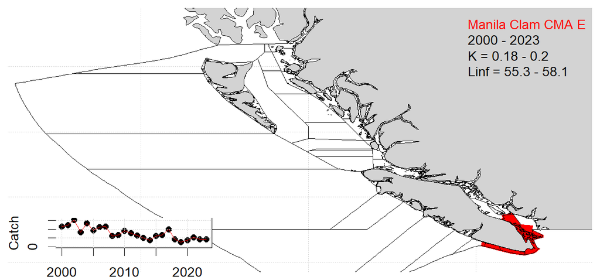

```r
about(In.MC.E) # information about the location and OM for manila clam in clam management area E
```

Input objects are lists that include information about the geographic location of the stock (in this case CMA), the operating model (OM) and the available data (RCMdata):

```r
class(In.MC.E)
```

```
#> [1] "In"
```

```r
names(In.MC.E)
```

```
#> [1] "CMA"     "OM"      "RCMdata"
```

We can make changes to model parameters (OM) or data (RCMdata) by manipulating these input objects.

## 12.2 Changing parameters

Operating models are built from the parameter ranges specified in the operating model object and a ‘custom parameter’ slot in the operating model.

```r
myOM = In.MC.E$OM
slotNames(myOM) # most of these are parameter ranges for uniform sampling of values
```

```
#>  [1] "Name"          "Agency"        "Region"        "Sponsor"
#>  [5] "Latitude"      "Longitude"     "nsim"          "proyears"
#>  [9] "interval"      "pstar"         "maxF"          "reps"
#> [13] "cpars"         "seed"          "Source"        "Common_Name"
#> [17] "Species"       "maxage"        "R0"            "M"
#> [21] "Msd"           "h"             "SRrel"         "Perr"
#> [25] "AC"            "Linf"          "Linfsd"        "K"
#> [29] "Ksd"           "t0"            "LenCV"         "L50"
#> [33] "L50_95"        "D"             "a"             "b"
#> [37] "Size_area_1"   "Frac_area_1"   "Prob_staying"  "Fdisc"
#> [41] "nyears"        "CurrentYr"     "EffYears"      "EffLower"
#> [45] "EffUpper"      "Esd"           "qinc"          "qcv"
#> [49] "L5"            "LFS"           "Vmaxlen"       "isRel"
#> [53] "LR5"           "LFR"           "Rmaxlen"       "DR"
#> [57] "Spat_targ"     "MPA"           "Misc"          "Cobs"
#> [61] "Cbiascv"       "CAA_nsamp"     "CAA_ESS"       "CAL_nsamp"
#> [65] "CAL_ESS"       "Iobs"          "Btobs"         "Btbiascv"
#> [69] "beta"          "LenMbiascv"    "Mbiascv"       "Kbiascv"
#> [73] "t0biascv"      "Linfbiascv"    "LFCbiascv"     "LFSbiascv"
#> [77] "FMSY_Mbiascv"  "BMSY_B0biascv" "Irefbiascv"    "Brefbiascv"
#> [81] "Crefbiascv"    "Dbiascv"       "Dobs"          "hbiascv"
#> [85] "Recbiascv"     "sigmaRbiascv"  "Eobs"          "Ebiascv"
#> [89] "TACFrac"       "TACSD"         "TAEFrac"       "TAESD"
#> [93] "SizeLimFrac"   "SizeLimSD"
```

```r
names(myOM@cpars) # these are higher level, per simulation samples specifed by the user
```

```
#> [1] "SLarray"     "CAL_binsmid" "L50"         "K"           "Linf"
#> [6] "Wa"          "M"
```

Operating model building first looks for the bespoke inputs of the custom parameters before settling on the parameter ranges. For example the operating models will use OM@cpars$M before they use OM@M:

```r
validcpars() # list all the custom parameter options
```

|  | Var. | Dim. | Desc. | Type |
| --- | --- | --- | --- | --- |
| 1 | R0 | numeric vector length nsim | Virgin recruitment | Stock |
| 2 | M | numeric vector length nsim | Natural mortality | Stock |
| 3 | Msd | numeric vector length nsim | Inter-annual variability in M | Stock |
| 4 | h | numeric vector length nsim | Steepness | Stock |
| 5 | SRrel | numeric vector length nsim | Stock-Recruit Relationship | Stock |
| 6 | Perr | numeric vector length nsim | Recruitment process error | Stock |
| 7 | AC | numeric vector length nsim | Recruitment auto-correlation | Stock |
| 8 | Linf | numeric vector length nsim | von B asymptotic length | Stock |
| 9 | Linfsd | numeric vector length nsim | Inter-annual variability in Linf | Stock |
| 10 | K | numeric vector length nsim | von B growth coefficient | Stock |

[output cut: 139 more lines]

```r
length(myOM@cpars$M) # nsim samples of the instantaneous natural mortality rate
```

```
#> [1] 500
```

```r
dim(myOM@cpars$SLarray) # fishery selectivity by simulation (500), length class (45) and year (54)
```

```
#> [1] 500  45  54
```

If you wanted to create the same OM but with an M value that is 20% lower you would do this:

```r
myOM = In.MC.E$OM
prevM = In.MC.E$OM@cpars$M
myOM@cpars$M = prevM * 0.8
```

If you wanted to sample your own M distribution and put it in the cpars slot you could do this:

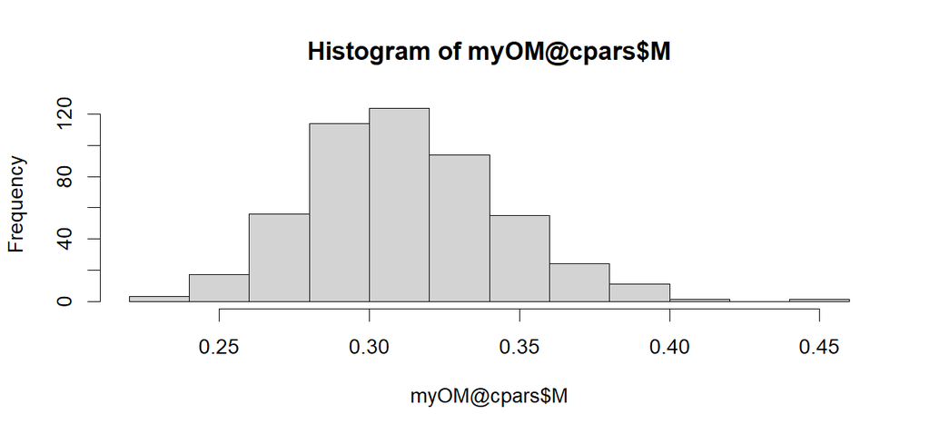

```r
nsim = myOM@nsim
myOM@cpars$M = rlnorm(nsim,log(0.31),0.1) # a lognormal distribution with median 0.31 and sd 0.1
hist(myOM@cpars$M )
```

## 12.3 Adding data / reconditioning operating models

The data used in conditing are stored in the slot RCMdata (rapid conditioning model data object). These data are of class RCMdata and have a defined format.

```r
mydata = In.MC.E$RCMdata
slotNames(mydata)
```

```
#>  [1] "Chist"      "C_sd"       "C_wt"       "Ehist"      "CAA"
#>  [6] "CAA_ESS"    "CAL"        "CAL_ESS"    "length_bin" "MS"
#> [11] "MS_type"    "MS_cv"      "Index"      "I_sd"       "I_wt"
#> [16] "IAA"        "IAA_ESS"    "IAL"        "IAL_ESS"    "C_eq"
#> [21] "C_eq_sd"    "E_eq"       "abs_I"      "I_units"    "I_delta"
#> [26] "age_error"  "sel_block"  "Misc"
```

```r
class?RCMdata
```

The two principle sources of data in this manila clam data object are historical catches (Chist) and Catch-at-length composition data (CAL) and three indices (Density survey, ICMP and a weak index prior for testing). Chist is a vector n_years long, CAL is a matrix nyears by n_length_categories:

```r
mydata = In.MC.E$RCMdata
myOM= In.MC.E$OM
myOM@nyears                   # the operating model historical time period
```

```
#> [1] 24
```

```r
length(mydata@Chist)          # check nyears in the OM matches Chist vector length
```

```
#> [1] 24
```

```r
length(mydata@length_bin)     # the number of length bins for the length composition data
```

```
#> [1] 45
```

```r
dim(mydata@CAL)               # check that the dimensions of the CAL data match up
```

```
#> [1] 24 45
```

```r
dim(mydata@IAA)               # check index age observations
```

```
#> [1] 24 16  3
```

```r
dim(mydata@Index)              # check that the index data dimensions match up
```

```
#> [1] 24  3
```

We are going to add some fake data (the mean catch and indices of the historical series, an old year of CAL data) to these datasets to demonstrate how this is done.

```r
mydata@Chist = c(mydata@Chist, mean(mydata@Chist))
mydata@Index = rbind(mydata@Index,apply(mydata@Index,2,mean,na.rm=T))
mydata@CAL = rbind(mydata@CAL, mydata@CAL[13,]) # 13th year, last year of CAL obs in the dataset is replicated
mydata@IAA = mydata@IAA[c(1:myOM@nyears,myOM@nyears),,] # replicate last year of index age observations

length(mydata@Chist)
```

```
#> [1] 25
```

```r
dim(mydata@CAL)
```

```
#> [1] 25 45
```

```r
dim(mydata@IAA)
```

```
#> [1] 25 16  3
```

We have a few things left to do: we need to specify the precision of the new observations of catch and catch-at-length and specify the new number of years in the operating model.

```r
mydata@C_sd = c(mydata@C_sd,mean(mydata@C_sd))
mydata@I_sd = rbind(mydata@I_sd, apply(mydata@I_sd, 2, mean,na.rm=T))
mydata@CAL_ESS = c(mydata@CAL_ESS, mydata@CAL_ESS[13]) # 13th year, last year of CAL age sample size
mydata@IAA_ESS = mydata@IAA_ESS[c(1:myOM@nyears,myOM@nyears),] # replicate last year of index age sample size
myOM@cpars$SLarray = myOM@cpars$SLarray[,,c(1,1:(myOM@nyears+myOM@proyears))] # add another year of size at length
myOM@nyears = myOM@nyears+1 # make sure OM has extra year
myOM@CurrentYr = myOM@CurrentYr+1
```

Now you have a fully specified RCMdata input object and compatible operating model, we can fit the new model and plot results:

```r
myinput = In.MC.E
myinput$OM = myOM
myinput$RCMdata = mydata
myfit = cond.MC(myinput)

plot(myfit)
```

# 13 Resources

## 13.1 B.C. Hand-harvested invertebrates splash page

For more information about how operating models were specified for B.C. invertebrates you can visit the [splash page](https://mis-assess.github.io/csrf_hh_io/)

Contact (tom@bluematterscience for password)

## 13.2 B.C. Hand-harvested invertebrates GitHub repository

All of the code for conditioning operating models can be found at a private [GitHub repository](https://github.com/mis-assess/csrf_hh_data) (contact Mackensie Mazur or Shannon Obradovich for access)

## 13.3 Inverts R packages

The code for the R packages used in this manaual are available from public GitHub repositories:

- Inverts
- Inverts.GD
- Inverts.MC
- Inverts.GSU
- Inverts.RSC

## 13.4 OpenMSE

Visit the [OpenMSE website](https://openmse.com) for more information on the framework including tutorial and case studies.

The Rapid Conditioning Model is also [described there](https://openmse.com/tutorial-rcm)

Other useful openMSE apps include [MERA](https://www.merafish.org/) for rapidly scoping operating models and [Reference Point Calculator](https://shiny.bluematterscience.com/app/rpc) for investigating reference points and control rules.

## 13.5 Management Strategy Evaluation

The Ocean Foundation host the [Harvest Strategies website](https://harveststrategies.org/) which is an excellent resource describing MSE, MSE concepts and how MSE can be used in fishery management including introductory videos and interviews with experts. ‘Harvest strategy’ and Management Procedure are synonymous, by the way.

# 14 References

Hordyk, A., Huynh, Q., Carruthers, T. 2025. OpenMSE: An open-source R package for Management strategy evaluation, available from: https://openmse.com

Huynh, Q., 2025. Rapid Conditioning model. Available from https://openmse.com/tutorial-rcm/

Punt, A.E., Butterworth, D.S., de Moor, C.L., De Oliveira, J.A.A., and Haddon, M. 2016. Management strategy evaluation: Best practices. Fish Fish. 17(2): 303–334. doi:10.1111/faf.12104.